# Chapter 8 Applied Exercises

## Part 10.b)

```r
train = 1:200
test = -train
```

## Part 10.c)

We want to draw training MSE as a function of the shrinkage parameter.

```r
# grid for lambda
(lambda_grid <- 10^seq(0, -4, length = 9))
```

```
## [1] 1.0000000000 0.3162277660 0.1000000000 0.0316227766 0.0100000000
## [6] 0.0031622777 0.0010000000 0.0003162278 0.0001000000
```

```r
# training MSE
library(gbm)
```

```r
library(ggplot2)
set.seed(1)
gbm_fits <- vector(mode = "list", length = length(lambda_grid))
gbm_train_preds <- vector(mode = "list", length = length(lambda_grid))
gbm_train_mse <- vector(length = length(lambda_grid))
for (i in 1:length(lambda_grid)) {
  gbm_fits[[i]] <- gbm(lsalary ~ ., data = Hits[train, ], distribution = "gaussian",
         n.trees = 1000, interaction.depth = 1, shrinkage = lambda_grid[i])
  gbm_train_preds[[i]] <- predict(gbm_fits[[i]], newdata = Hits[train, ], n.trees = 1000)
  gbm_train_mse[i] <- mean((Hits$lsalary[train] - gbm_train_preds[[i]])^2)
}
```

Here is the plot:

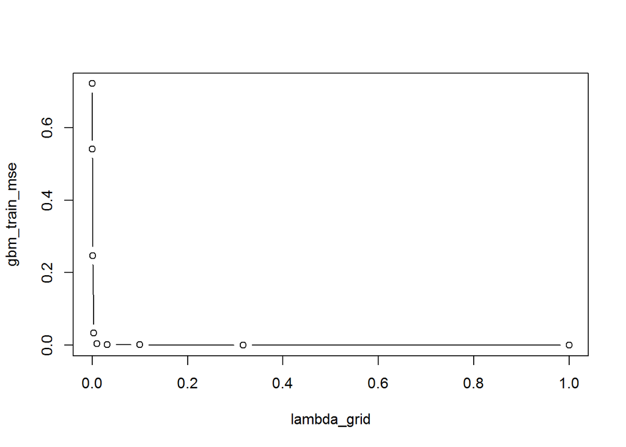

```r
plot(lambda_grid, gbm_train_mse, type = "b")
```

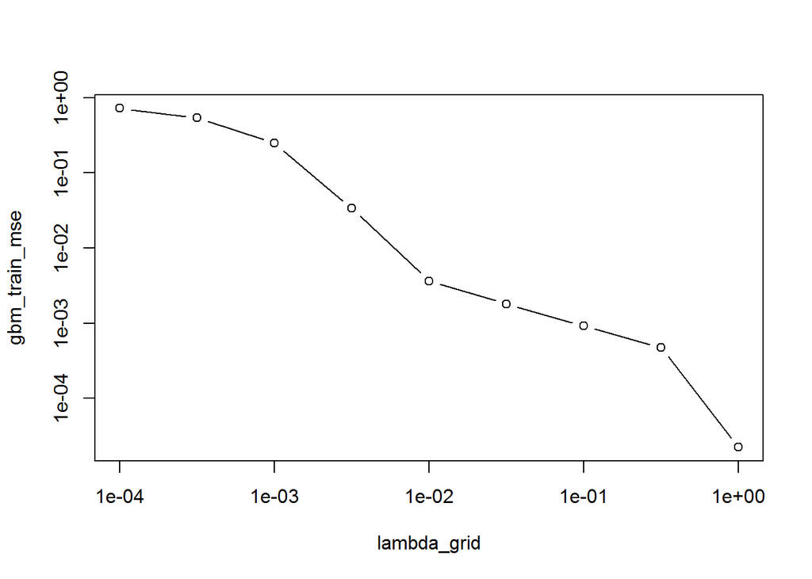

```r
plot(lambda_grid, gbm_train_mse, log = "xy", type = "b")
```

## Part 10.d)

To enable working with different combinations, we write a function:

```r
test_mse_ex10 <-
  function(data, lambda.grid, n.trees) {
    set.seed(1)
    gbm_test_mse <- rep(NA, length = length(lambda.grid))
      for (i in 1:length(lambda.grid)) {
        gbm_fit <- gbm(lsalary ~ . - Salary - lsalary, data = data[train, ], distribution = "gaussian",
                 shrinkage = lambda.grid[i], interaction.depth = 1, n.trees = n.trees)
        gbm_preds <- predict(gbm_fit, newdata = data[test, ], n.tree = n.trees)
        gbm_test_mse[i] <- mean((data$lsalary[test] - gbm_preds)^2)
      }
  gbm_test_mse
  }
```

We use the same grid for the test MSE.

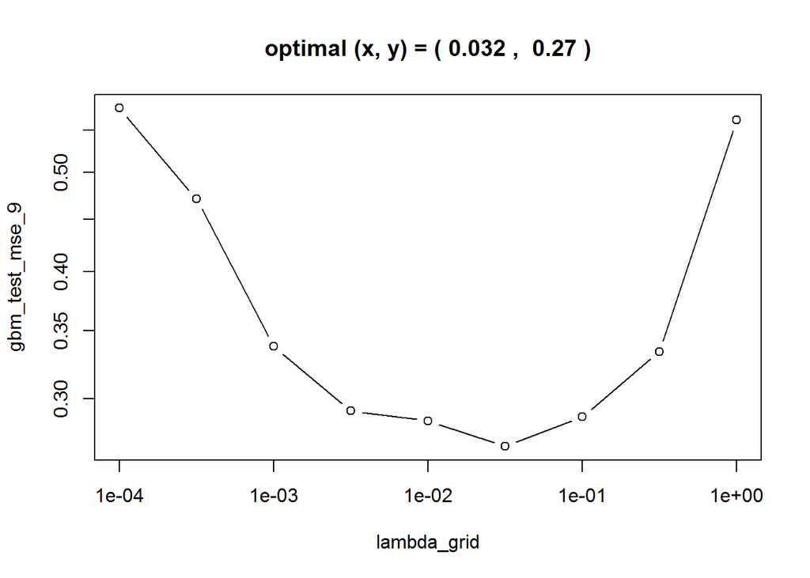

```r
gbm_test_mse_9 <- test_mse_ex10(Hits, lambda.grid = lambda_grid, n.trees = 1000)
opt_mse_9 <- c(lambda_grid[gbm_test_mse_9 == min(gbm_test_mse_9)],
             min(gbm_test_mse_9))
plot(lambda_grid, gbm_test_mse_9, log = "xy", type = "b")
title(paste("optimal (x, y) = (", round(opt_mse_9[1], 3), ", ", round(opt_mse_9[2], 3), ")"))
```

We can prove that the minimum in the log-log plot is the same as the minimum in the non-transformed plot, since $x$ and $y$ are positive (it can be shown using the fact that $\frac{d \log(y)}{d \log(x)}=\frac{dy}{dx}\times \frac{x}{y}$, so whenever the derivative of the non-transformed function changes sign from negative to positive, so the does the derivative of transfromed). Since we do not have many grid points, the optimal point might not be the minimum point in the plot above. Below, we use a finer grid, but noly only increasing the number of grid points to 20, but also narrowing our focus on a smaller region:

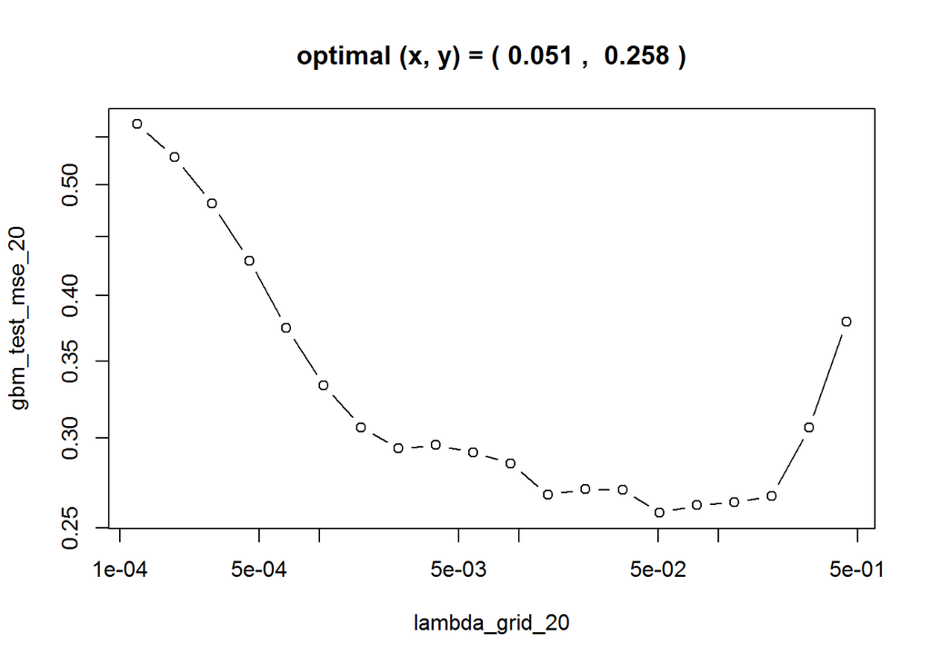

```r
lambda_grid_20 <- 10^seq(from = log(0.02), to = log(0.7), length = 20)
gbm_test_mse_20 <- test_mse_ex10(Hits, lambda.grid = lambda_grid_20, n.trees = 1000)
opt_mse_20 <- c(lambda_grid_20[gbm_test_mse_20 == min(gbm_test_mse_20)],
             min(gbm_test_mse_20))
plot(lambda_grid_20, gbm_test_mse_20, log = "xy", type = "b")
title(paste("optimal (x, y) = (", round(opt_mse_20[1], 3), ", ", round(opt_mse_20[2], 3), ")"))
```

```r
c(lambda_grid_20[gbm_test_mse_20 == min(gbm_test_mse_20)], min(gbm_test_mse_20))
```

```
## [1] 0.05101609 0.25788970
```

An interesting point is that the test MSE seems to be sensitive to the amount of $\lambda$, in the sense that a small change in $\lambda$ may casue a relatively large change in the test MSE. This is better seen using a finer grid, which we will investigate in the next subsection. However, we will use the amount of $\lambda$ we find here in the next rest of the exercise.

### Digression: the effect of finder grids

The picture below shows the change in the plot if we only increase the number of grid points from 20 to 100, given the same interval:

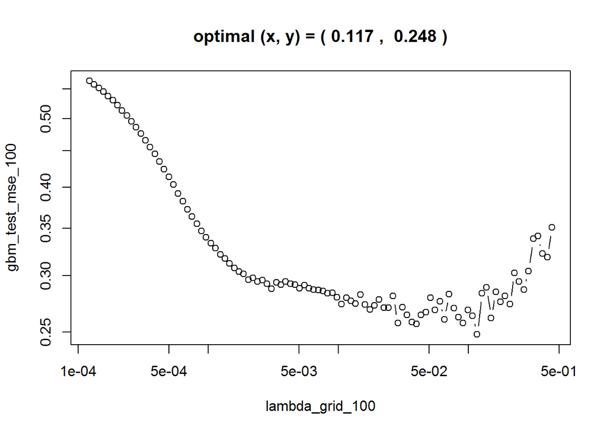

```r
lambda_grid_100 <- 10^seq(from = log(0.02), to = log(0.7), length = 100)
gbm_test_mse_100 <- test_mse_ex10(Hits, lambda.grid = lambda_grid_100, n.trees = 1000)
opt_mse <- c(lambda_grid_100[gbm_test_mse_100 == min(gbm_test_mse_100)],
             min(gbm_test_mse_100))
plot(lambda_grid_100, gbm_test_mse_100, log = "xy", type = "b")
title(paste("optimal (x, y) = (", round(opt_mse[1], 3), ", ", round(opt_mse[2], 3), ")"))
```

Below we look even closer. Even a closer look shows us that the optimal $\lambda$ should be between 0.02 and 0.2. But, due to the fluctuations, it does not give us much information beyond that. So we keep the number of grid points equal to 100, but narrow the interval:

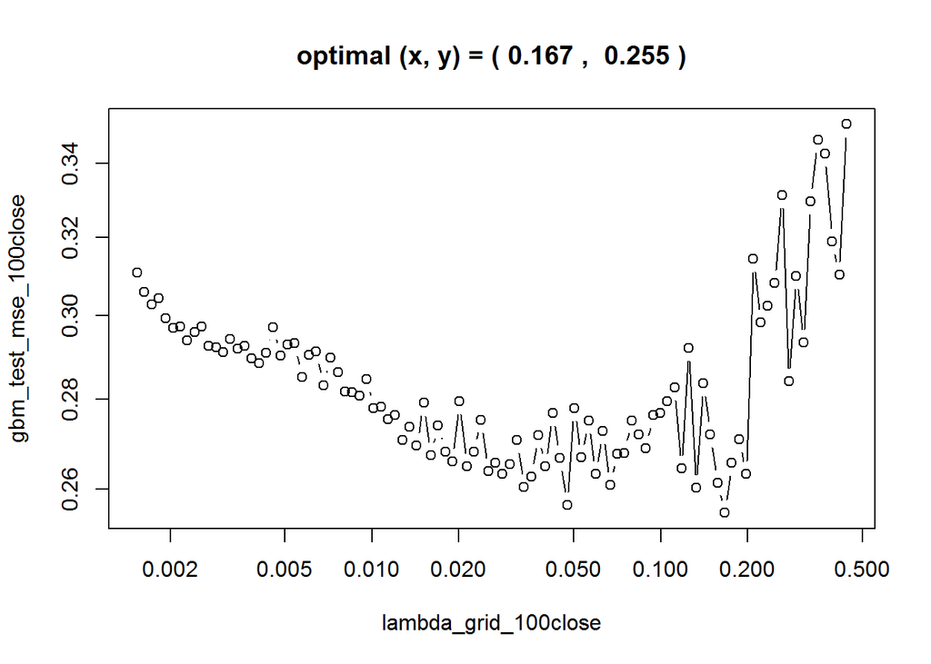

```r
lambda_grid_100close <- 10^seq(from = log(0.06), to = log(0.7), length = 100)
gbm_test_mse_100close <-
  test_mse_ex10(Hits, lambda.grid = lambda_grid_100close, n.trees = 1000)
opt_mse <- c(lambda_grid_100close[gbm_test_mse_100close == min(gbm_test_mse_100close)],
             min(gbm_test_mse_100close))
plot(lambda_grid_100close, gbm_test_mse_100close, log = "xy", type = "b")
title(paste("optimal (x, y) = (", round(opt_mse[1], 3), ", ", round(opt_mse[2], 3), ")"))
```

How would the optimal $\lambda$ change when we increase the number of trees? Does it improve the test MSE? We keep the narrowest interval we experimated with, as the previous plot, and increase the number of trees from 1000 to 5000:

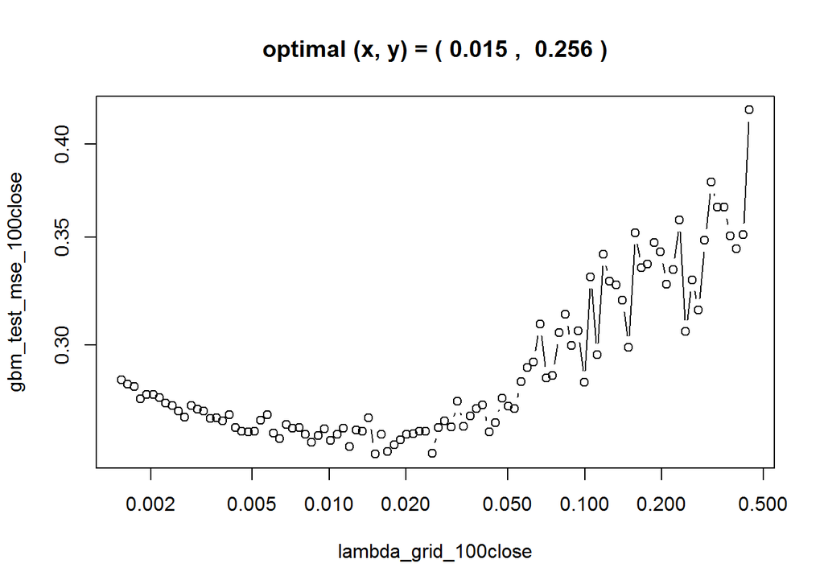

```r
lambda_grid_100close <- 10^seq(from = log(0.06), to = log(0.7), length = 100)
gbm_test_mse_100close <- test_mse_ex10(Hits, lambda.grid = lambda_grid_100close, n.trees = 5000)
opt_mse <- c(lambda_grid_100close[gbm_test_mse_100close == min(gbm_test_mse_100close)], min(gbm_test_mse_100close))
plot(lambda_grid_100close, gbm_test_mse_100close, log = "xy", type = "b")
title(paste("optimal (x, y) = (", round(opt_mse[1], 3), ", ", round(opt_mse[2], 3), ")"))
```

In this example, optimal $\lambda$ decreases when we increase the number of trees, which is in line with the idea that when we have more trees, we can have slower pace of learning.

The test MSE is very close in all cases we studied above, except for the case where we had only 9 grid points. Hence, in this example, we would have been fine as long as we used a moderate number of grid points. However, note that this is a very small dataset and we are using only 63 observations for the test data.

## Part 10.e)

Chapter 3 covered linear regression and chapter 6 covered subset selection, shrinkage and dimension reduction methods. The questions asks for combining linear regression with either of the methods in chapter 6. We will work only with linear variables, so will not make any higher-order transformation.

### Best subset selection

We use cross-validation with 5 folds.

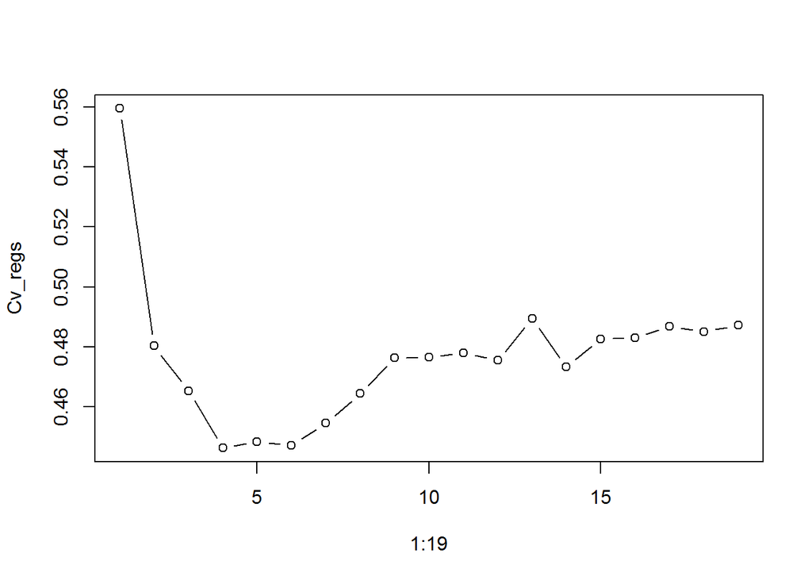

```r
library(leaps)
set.seed(1)
## define the predict function for regsubsets:
predict.regsubsets =
  function (object, newdata ,id, ...) {
    form = as.formula(object$call[[2]])
    mat = model.matrix(form, newdata)
    coefi = coef(object, id = id)
    xvars = names(coefi)
    mat[,xvars]%*%coefi
  }
## Compute CV error
# define folds
folds <- sample(1:5, size = length(train), replace = TRUE)
# to avoid confusion of training set with different training data in cv
Hits_cv <- Hits[train, ]
Cv_mat <- matrix(NA, nrow = 19, ncol = 5)
for (j in 1:5) {
  regfit_j <- regsubsets(lsalary ~ . - Salary, data = Hits_cv[folds != j, ], nvmax = 19)
  for (i in 1:19) {
    preds_ij <- predict(regfit_j, Hits_cv[folds == j, ], id = i)
    Cv_mat[i, j] <- mean((preds_ij - Hits_cv$lsalary[folds == j])^2)
  }
}
Cv_regs <- apply(Cv_mat, FUN = mean, MARGIN = 1)
plot(1:19, Cv_regs, type = "b")
```

The plot above implies that the optimal size is 4, i.e. with four variables. Now, we should retrieve the best model of size 4 using full training data (so far we have only used 4 folds out of 5 as training data in cross-validation):

```r
regfit_full <- regsubsets(lsalary ~ . - Salary, data = Hits[train, ],
                          nvmax = 4)  # four variables is enough
preds2 <- predict(regfit_full, newdata = Hits[test, ], id = 4)
(mse_best2 <- mean((preds2 - Hits$lsalary[test])^2))
```

```
## [1] 0.4942052
```

### Ridge regression

```r
library(glmnet)
Hits_x = model.matrix(lsalary ~ . - Salary, data = Hits)[, -1]
lambda_grid <- 10^seq(10, -2, length = 100)
fit_ridge <- glmnet(x = Hits_x[train, ], y =  Hits$lsalary[train], alpha = 0,
       lambda = lambda_grid, thresh = 1e-12)
cv_ridge <- cv.glmnet(x = Hits_x[test, ], y = Hits$lsalary[test], alpha = 0)
best_lam <- cv_ridge$lambda.min
preds_ridge <- predict(fit_ridge, s = best_lam, newx = Hits_x[test, ])
(mse_ridge <- mean((preds_ridge - Hits$lsalary[test])^2))
```

```
## [1] 0.4424325
```

### Lasso regression

```r
library(glmnet)
Hits_x = model.matrix(lsalary ~ . - Salary, data = Hits)[, -1]
lambda_grid <- 10^seq(10, -2, length = 100)
fit_lasso <- glmnet(x = Hits_x[train, ], y =  Hits$lsalary[train], alpha = 1,
       lambda = lambda_grid, thresh = 1e-12)
cv_lasso <- cv.glmnet(x = Hits_x[test, ], y = Hits$lsalary[test], alpha = 1)
best_lam <- cv_lasso$lambda.min
preds_lasso <- predict(fit_lasso, s = best_lam, newx = Hits_x[test, ])
(mse_lasso <- mean((preds_lasso - Hits$lsalary[test])^2))
```

```
## [1] 0.4398225
```

### PCR

```r
library(pls)
pcr_fit <- pcr(lsalary ~ . - Salary, data = Hits[train, ],
    scale = TRUE, validation = "CV")
summary(pcr_fit)
```

```
## Data:    X dimension: 200 19
##  Y dimension: 200 1
## Fit method: svdpc
## Number of components considered: 19
##
## VALIDATION: RMSEP
## Cross-validated using 10 random segments.
##        (Intercept)  1 comps  2 comps  3 comps  4 comps  5 comps  6 comps
## CV          0.9167   0.6336   0.6374   0.6390   0.6390   0.6324   0.6330
## adjCV       0.9167   0.6333   0.6369   0.6383   0.6382   0.6315   0.6318
##        7 comps  8 comps  9 comps  10 comps  11 comps  12 comps  13 comps
## CV      0.6344   0.6364   0.6372    0.6407    0.6426    0.6456    0.6444
## adjCV   0.6332   0.6346   0.6353    0.6385    0.6404    0.6431    0.6415
##        14 comps  15 comps  16 comps  17 comps  18 comps  19 comps
## CV       0.6426    0.6444    0.6305    0.6304    0.6347    0.6333
## adjCV    0.6395    0.6412    0.6276    0.6269    0.6310    0.6296
##
## TRAINING: % variance explained
##          1 comps  2 comps  3 comps  4 comps  5 comps  6 comps  7 comps
## X          39.40    60.67    70.76    79.64    84.73    89.29    92.38
## lsalary    52.42    52.67    53.22    53.56    54.56    55.34    55.70
##          8 comps  9 comps  10 comps  11 comps  12 comps  13 comps
## X          95.02    96.32     97.26     98.06     98.72     99.23
## lsalary    56.48    56.68     56.77     56.80     57.41     57.91
##          14 comps  15 comps  16 comps  17 comps  18 comps  19 comps
## X           99.54     99.77     99.90     99.97     99.99    100.00
## lsalary     58.68     58.75     60.27     61.27     61.27     61.49
```

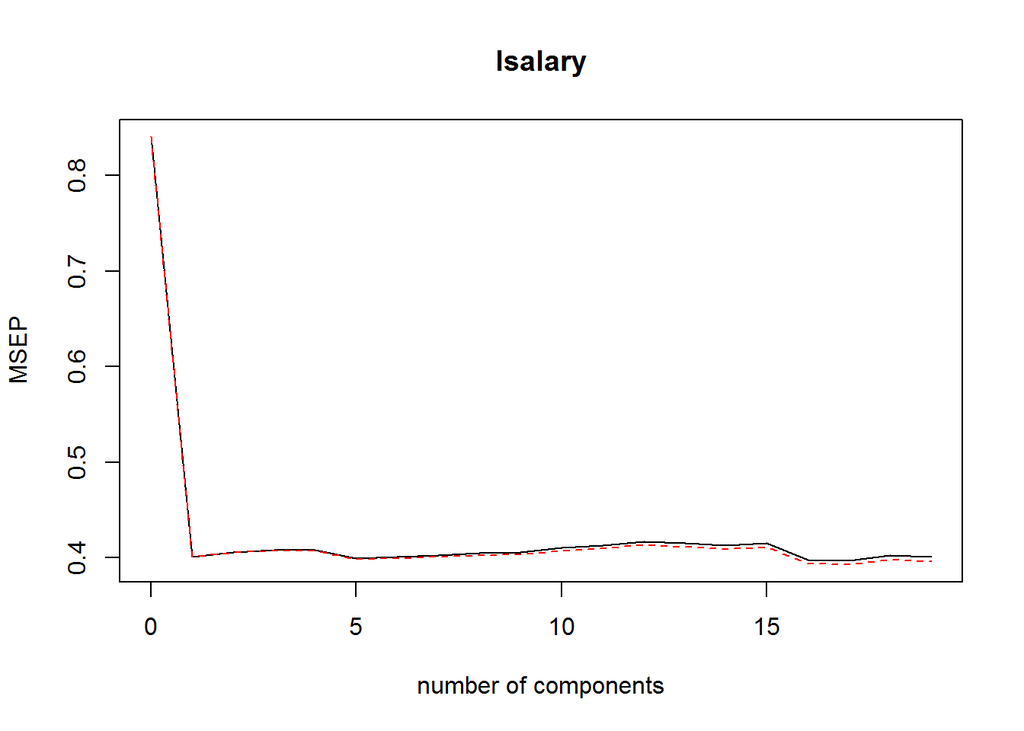

```r
validationplot(pcr_fit, val.type = "MSEP")
```

Choosing 1 component gives a reasonable cross-validation error.

```r
preds_pcr <- predict(pcr_fit, newdata = Hits[test, ], ncomp = 1)
(cv_pcr <- mean((preds_pcr - Hits$lsalary[test])^2))
```

```
## [1] 0.4661183
```

The performance of boosting is impressive: it leads to test MSE estimate of about 0.26, while the best performance we get from the combination of a linear model with methods of chapter 6 is more than 0.43. This is despite the fact that we use an additive boosing model (we use stumps). This is an indication of nonlinearity in the data.

## Part 10.f)

We use the value of $\lambda$ we found with 20 grids, and use the full data:

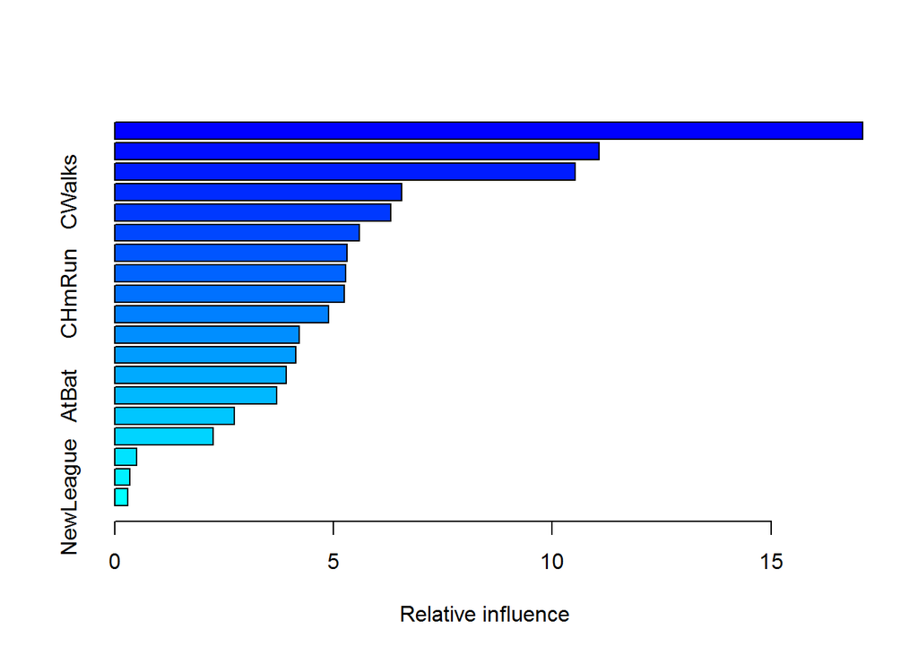

```
##                 var    rel.inf
## CAtBat       CAtBat 17.0952907
## CRBI           CRBI 11.0769797
## CHits         CHits 10.5285551
## CWalks       CWalks  6.5644198
## CRuns         CRuns  6.3014537
## Years         Years  5.5972824
## Walks         Walks  5.3090311
## Hits           Hits  5.2856063
## CHmRun       CHmRun  5.2416846
## PutOuts     PutOuts  4.8958056
## RBI             RBI  4.2241857
## HmRun         HmRun  4.1355981
## Runs           Runs  3.9128950
## AtBat         AtBat  3.7021136
## Errors       Errors  2.7403018
## Assists     Assists  2.2520485
## League       League  0.4980133
## Division   Division  0.3436503
## NewLeague NewLeague  0.2950848
```

```r
best_lam <- lambda_grid_20[gbm_test_mse_20 == min(gbm_test_mse_20)]
gbm_fit <- gbm(lsalary ~ . - Salary - lsalary, data = Hits, distribution = "gaussian",
        shrinkage = best_lam, interaction.depth = 1, n.trees = 1000)
summary(gbm_fit)
```

`CAtBat` appears to be the most important variable. Perhaps more interestingly, the variables that measure values during the career seem to be much more important that the same-season measurements.

## Part 10.g)

The bagging test MSE:

```r
library(randomForest)
rf_fit <- randomForest(lsalary ~ . - Salary, data = Hits[train, ],
                       mtry = 19, ntree = 500, importance = TRUE)
rf_preds <- predict(rf_fit, newdata = Hits[test, ])
(rf_mse <- mean((rf_preds - Hits$lsalary[test])^2))
```

```
## [1] 0.22887
```

The test MSE is slightly smaller than the one we found for boosting. This might be because of using an additive model for boosting, while the bagging estimator is more flexible.

# Exercise 11

```r
library(ISLR)
# the data
dim(Caravan)  # 86 variables
```

```
## [1] 5822   86
```

```r
sum(is.na(Caravan))
```

```
## [1] 0
```

```r
# response
summary(Caravan$Purchase)
```

```
##   No  Yes
## 5474  348
```

```r
contrasts(Caravan$Purchase)
```

```
##     Yes
## No    0
## Yes   1
```

`gbm()` with a qualitative variable as response requires transformation to a 0-1 dummy variable:

```r
Caravan$Purchase <- ifelse(Caravan$Purchase == "Yes", 1, 0)
summary(Caravan$Purchase)
```

```
##    Min. 1st Qu.  Median    Mean 3rd Qu.    Max.
## 0.00000 0.00000 0.00000 0.05977 0.00000 1.00000
```

## Part 11.a)

```r
train = 1:1000
test = -train
```

## Part 11.b)

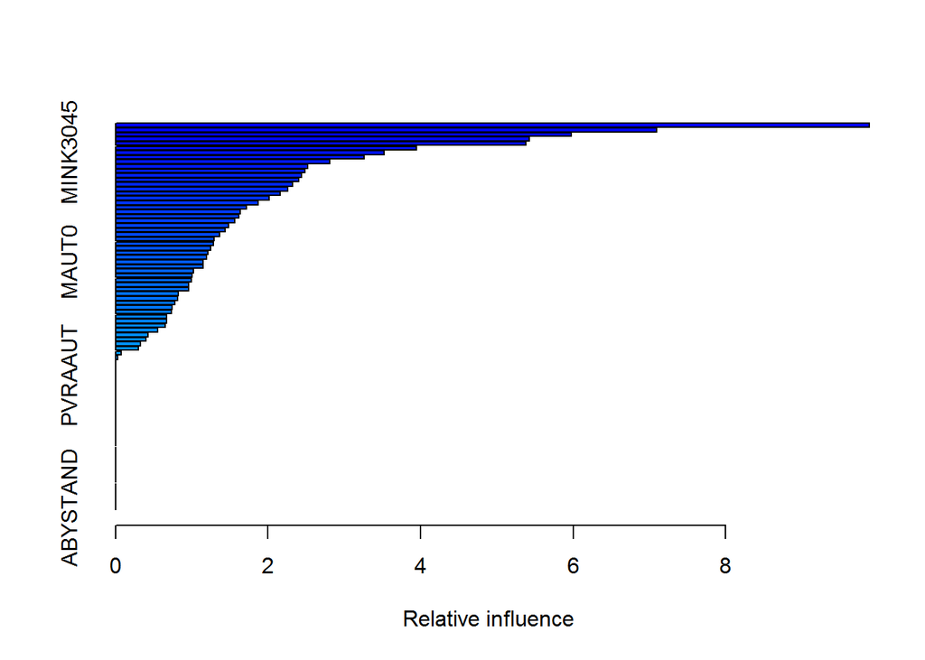

```
##               var    rel.inf
## PPERSAUT PPERSAUT 9.88196755
## MKOOPKLA MKOOPKLA 7.09057539
## MOPLHOOG MOPLHOOG 5.97383721
## PBRAND     PBRAND 5.42795341
## MGODGE     MGODGE 5.37533300
## MBERMIDD MBERMIDD 3.94847387
## MINK3045 MINK3045 3.51763123
## MGODPR     MGODPR 3.25916272
## MOSTYPE   MOSTYPE 2.81168103
## MBERARBG MBERARBG 2.52290762
## ABRAND     ABRAND 2.48318472
## MAUT2       MAUT2 2.43784324
## MSKA         MSKA 2.39996975
## MAUT1       MAUT1 2.32463277
## MSKC         MSKC 2.25575413
## PWAPART   PWAPART 2.15817221
## MSKB1       MSKB1 2.01054800
## MINK7512 MINK7512 1.86610130
## MFGEKIND MFGEKIND 1.71887449
## MFWEKIND MFWEKIND 1.63896537
## MRELGE     MRELGE 1.61226288
## MBERHOOG MBERHOOG 1.56162484
## MGODOV     MGODOV 1.47899843
## MINKGEM   MINKGEM 1.44042382
## MZFONDS   MZFONDS 1.36297740
## MOPLMIDD MOPLMIDD 1.29452540
## MGODRK     MGODRK 1.28364889
## APERSAUT APERSAUT 1.24368912
## MINK4575 MINK4575 1.21344684
## MRELOV     MRELOV 1.19368544
## MAUT0       MAUT0 1.14689401
## MHHUUR     MHHUUR 1.14420398
## MGEMLEEF MGEMLEEF 1.02514716
## MZPART     MZPART 1.00085325
## MHKOOP     MHKOOP 0.99160310
## MINKM30   MINKM30 0.96171242
## MOSHOOFD MOSHOOFD 0.96138547
## PBYSTAND PBYSTAND 0.82501502
## PMOTSCO   PMOTSCO 0.81362486
```

[output cut: 31 more lines]

```
## ABESAUT   ABESAUT 0.00000000
## AMOTSCO   AMOTSCO 0.00000000
## AVRAAUT   AVRAAUT 0.00000000
## AAANHANG AAANHANG 0.00000000
## ATRACTOR ATRACTOR 0.00000000
## AWERKT     AWERKT 0.00000000
## ABROM       ABROM 0.00000000
## APERSONG APERSONG 0.00000000
## AGEZONG   AGEZONG 0.00000000
## AWAOREG   AWAOREG 0.00000000
## AZEILPL   AZEILPL 0.00000000
## APLEZIER APLEZIER 0.00000000
## AFIETS     AFIETS 0.00000000
## AINBOED   AINBOED 0.00000000
## ABYSTAND ABYSTAND 0.00000000
```

```r
library(gbm)
set.seed(1)
gbm_fit <- gbm(Purchase ~ ., data = Caravan[train, ], distribution = "bernoulli",
               interaction.depth = 2, n.trees = 1000, shrinkage = 0.01)
summary(gbm_fit)
```

`PPERSAUT` seems to be the most important determinant of `Purchase`.

## Part 11.c)

```r
library(gmodels)
gbm_probs <- predict(gbm_fit, newdata = Caravan[test, ], n.trees = 1000, type = "response")
gbm_preds <- ifelse(gbm_probs > 0.2, 1, 0)
CrossTable(gbm_preds, Caravan$Purchase[test])
```

```
##
##
##    Cell Contents
## |-------------------------|
## |                       N |
## | Chi-square contribution |
## |           N / Row Total |
## |           N / Col Total |
## |         N / Table Total |
## |-------------------------|
##
##
## Total Observations in Table:  4822
##
##
##              | Caravan$Purchase[test]
##    gbm_preds |         0 |         1 | Row Total |
## -------------|-----------|-----------|-----------|
##            0 |      4359 |       252 |      4611 |
##              |     0.137 |     2.146 |           |
##              |     0.945 |     0.055 |     0.956 |
##              |     0.962 |     0.872 |           |
##              |     0.904 |     0.052 |           |
## -------------|-----------|-----------|-----------|
##            1 |       174 |        37 |       211 |
##              |     2.990 |    46.902 |           |
##              |     0.825 |     0.175 |     0.044 |
##              |     0.038 |     0.128 |           |
##              |     0.036 |     0.008 |           |
## -------------|-----------|-----------|-----------|
## Column Total |      4533 |       289 |      4822 |
##              |     0.940 |     0.060 |           |
## -------------|-----------|-----------|-----------|
##
##
```

17.5% of the people predicted to make a purchase do in fact make one. It is more accurate than the KNN and logistic predictions below.

### KNN

We try KNN with k = 2.

```r
library(class)
set.seed(1)
knn_preds <- knn(test = Caravan[test, ], train = Caravan[train, ], cl = Caravan$Purchase[train], k = 2)
CrossTable(knn_preds, Caravan$Purchase[test])
```

```
##
##
##    Cell Contents
## |-------------------------|
## |                       N |
## | Chi-square contribution |
## |           N / Row Total |
## |           N / Col Total |
## |         N / Table Total |
## |-------------------------|
##
##
## Total Observations in Table:  4822
##
##
##              | Caravan$Purchase[test]
##    knn_preds |         0 |         1 | Row Total |
## -------------|-----------|-----------|-----------|
##            0 |      4272 |       258 |      4530 |
##              |     0.043 |     0.671 |           |
##              |     0.943 |     0.057 |     0.939 |
##              |     0.942 |     0.893 |           |
##              |     0.886 |     0.054 |           |
## -------------|-----------|-----------|-----------|
##            1 |       261 |        31 |       292 |
##              |     0.664 |    10.413 |           |
##              |     0.894 |     0.106 |     0.061 |
##              |     0.058 |     0.107 |           |
##              |     0.054 |     0.006 |           |
## -------------|-----------|-----------|-----------|
## Column Total |      4533 |       289 |      4822 |
##              |     0.940 |     0.060 |           |
## -------------|-----------|-----------|-----------|
##
##
```

10.6% of those who are predicted to purchase in fact purchase according to the KNN.

### Logistic regression

We use the same threshold of 0.2 for logistic regression:

```r
glm_fit <- glm(Purchase ~ ., data = Caravan[train, ], family = "binomial")
glm_probs <- predict(glm_fit, newdata= Caravan[test, ], type = "response")
glm_preds <- ifelse(glm_probs > 0.2, 1, 0)
CrossTable(glm_preds, Caravan$Purchase[test])
```

```
##
##
##    Cell Contents
## |-------------------------|
## |                       N |
## | Chi-square contribution |
## |           N / Row Total |
## |           N / Col Total |
## |         N / Table Total |
## |-------------------------|
##
##
## Total Observations in Table:  4822
##
##
##              | Caravan$Purchase[test]
##    glm_preds |         0 |         1 | Row Total |
## -------------|-----------|-----------|-----------|
##            0 |      4183 |       231 |      4414 |
##              |     0.271 |     4.254 |           |
##              |     0.948 |     0.052 |     0.915 |
##              |     0.923 |     0.799 |           |
##              |     0.867 |     0.048 |           |
## -------------|-----------|-----------|-----------|
##            1 |       350 |        58 |       408 |
##              |     2.934 |    46.023 |           |
##              |     0.858 |     0.142 |     0.085 |
##              |     0.077 |     0.201 |           |
##              |     0.073 |     0.012 |           |
## -------------|-----------|-----------|-----------|
## Column Total |      4533 |       289 |      4822 |
##              |     0.940 |     0.060 |           |
## -------------|-----------|-----------|-----------|
##
##
```

For logistic regression, 14.2% of those who are predicted to purchuse do purchase.